# Creating 1-, 5- and 10-year averages for windows of exposure

Robbie Parks

16/06/20221

# Declare root directory, load folder locations, packages

# Load merged dataset (large dataset so be careful)

```r
full_dataset <- readRDS(paste0(robbie_datasets, "joined_datasets.rds"))
summary(full_dataset)
```

```
##        nr           lobnr       ck             diagtype    diagdat
##  Min.   :   2   Min.   :0.000   0:5734596   Min.   :1   Min.   :1989-01-02
##  1st Qu.:1341   1st Qu.:1.000   1:1149596   1st Qu.:1   1st Qu.:2000-03-04
##  Median :2664   Median :2.000               Median :1   Median :2006-03-13
##  Mean   :2552   Mean   :2.497               Mean   :1   Mean   :2004-12-23
##  3rd Qu.:3844   3rd Qu.:4.000               3rd Qu.:1   3rd Qu.:2010-06-16
##  Max.   :4608   Max.   :5.000               Max.   :1   Max.   :2013-12-30
##
##     year_gap             one_year            five_years
##  Min.   :1988-01-02   Min.   :1987-01-02   Min.   :1983-01-02
##  1st Qu.:1999-03-02   1st Qu.:1998-03-02   1st Qu.:1994-03-02
##  Median :2005-03-10   Median :2004-03-10   Median :2000-03-10
##  Mean   :2003-12-21   Mean   :2002-12-21   Mean   :1998-12-21
##  3rd Qu.:2009-06-07   3rd Qu.:2008-06-07   3rd Qu.:2004-06-07
##  Max.   :2012-12-30   Max.   :2011-12-30   Max.   :2007-12-30
##  NA's   :7137         NA's   :7137         NA's   :7137
##    ten_years                ID         aegtesocial          bdate
##  Min.   :1978-01-02   Min.   :    9   Min.   :1.0       Min.   :1901-02-06
##  1st Qu.:1989-03-02   1st Qu.:10705   1st Qu.:3.0       1st Qu.:1929-11-14
##  Median :1995-03-10   Median :21284   Median :4.0       Median :1938-12-02
##  Mean   :1993-12-21   Mean   :20381   Mean   :3.6       Mean   :1939-05-10
##  3rd Qu.:1999-06-07   3rd Qu.:30707   3rd Qu.:5.0       3rd Qu.:1947-05-02
##  Max.   :2002-12-30   Max.   :36806   Max.   :5.0       Max.   :1987-06-01
##  NA's   :7137                         NA's   :2574659
##   civst           civstdat5             d_inddto             d_uddto
##  1   : 664932   Min.   :1900-07-01   Min.   :1989-01-02   Min.   :1989-01-06
##  2   :1196793   1st Qu.:1962-08-04   1st Qu.:2000-03-07   1st Qu.:2000-08-03
##  3   : 841693   Median :1975-05-17   Median :2006-03-23   Median :2006-10-19
##  4   :4179669   Mean   :1976-07-12   Mean   :2004-12-31   Mean   :2005-07-08
##  NA's:   1105   3rd Qu.:1991-06-01   3rd Qu.:2010-07-12   3rd Qu.:2011-01-19
##                 Max.   :2013-08-30   Max.   :2013-12-30   Max.   :2014-11-01
##                 NA's   :664932
##     daars1             daars2               diag              diy
##  Length:6884192     Length:6884192     DG122  :5516319   Min.   :1989
##  Class :character   Class :character   DG122G : 896874   1st Qu.:2000
##  Mode  :character   Mode  :character   34809  : 411292   Median :2006
##                                        DG122F :  18925   Mean   :2004
##                                        DG122A :  12876   3rd Qu.:2010
##                                        DG122D :  10867   Max.   :2013
##                                        (Other):  17039
```

[output cut: 33 more lines]

```
##  Min.   :  1.572   Min.   :  90.16   Min.   : 0.0289   Min.   :  0.4666
##  1st Qu.: 11.171   1st Qu.: 187.93   1st Qu.: 0.5507   1st Qu.: 14.1007
##  Median : 14.476   Median : 244.88   Median : 0.8060   Median : 19.1741
##  Mean   : 15.139   Mean   : 282.02   Mean   : 0.9474   Mean   : 20.3902
##  3rd Qu.: 18.053   3rd Qu.: 321.68   3rd Qu.: 1.1712   3rd Qu.: 24.9813
##  Max.   :102.817   Max.   :3398.74   Max.   :15.4809   Max.   :100.3371
##  NA's   :1600      NA's   :1600      NA's   :1600      NA's   :1600
##     NOX_str             O3_str            PM10_str
##  Min.   :  0.5487   Min.   :  0.3113   Min.   :  3.986
##  1st Qu.: 16.3453   1st Qu.: 35.9618   1st Qu.: 17.284
##  Median : 23.9377   Median : 50.4190   Median : 20.586
##  Mean   : 30.5219   Mean   : 50.4873   Mean   : 21.309
##  3rd Qu.: 35.1733   3rd Qu.: 65.2587   3rd Qu.: 24.546
##  Max.   :515.6581   Max.   :144.9146   Max.   :123.447
##  NA's   :1600       NA's   :1600       NA's   :1600
```

# Nest data by cases so we can easily create windows of exposure for each case

```r
# A data set made up of sub-datasets. Each data subset corresponds to a patient and his/her controls
nested_data <- full_dataset %>%
  mutate(nr = as.factor(nr),
         lobnr = as.factor(lobnr),
         ck = as.factor(ck)) %>%
  group_by(nr) %>%
  nest()

# take a look in a single case and corresponding controls
test <- as.data.frame(nested_data$data[[1]]) %>%
 dplyr::filter(date_exp <= year_gap & date_exp >= one_year)

summary(test)
```

```
##  lobnr  ck        diagtype    diagdat              year_gap
##  0:12   0:60   Min.   :1   Min.   :1993-02-22   Min.   :1992-02-22
##  1:12   1:12   1st Qu.:1   1st Qu.:1993-02-22   1st Qu.:1992-02-22
##  2:12          Median :1   Median :1993-02-22   Median :1992-02-22
##  3:12          Mean   :1   Mean   :1993-02-22   Mean   :1992-02-22
##  4:12          3rd Qu.:1   3rd Qu.:1993-02-22   3rd Qu.:1992-02-22
##  5:12          Max.   :1   Max.   :1993-02-22   Max.   :1992-02-22
##
##     one_year            five_years           ten_years                ID
##  Min.   :1991-02-22   Min.   :1987-02-22   Min.   :1982-02-22   Min.   : 9.0
##  1st Qu.:1991-02-22   1st Qu.:1987-02-22   1st Qu.:1982-02-22   1st Qu.:10.0
##  Median :1991-02-22   Median :1987-02-22   Median :1982-02-22   Median :11.5
##  Mean   :1991-02-22   Mean   :1987-02-22   Mean   :1982-02-22   Mean   :11.5
##  3rd Qu.:1991-02-22   3rd Qu.:1987-02-22   3rd Qu.:1982-02-22   3rd Qu.:13.0
##  Max.   :1991-02-22   Max.   :1987-02-22   Max.   :1982-02-22   Max.   :14.0
##
##   aegtesocial      bdate            civst    civstdat5
##  Min.   :2.0   Min.   :1929-01-01   1: 0   Min.   :1952-09-20
##  1st Qu.:2.0   1st Qu.:1929-03-01   2: 0   1st Qu.:1952-11-02
##  Median :3.5   Median :1929-04-16   3: 0   Median :1954-07-13
##  Mean   :3.5   Mean   :1929-04-26   4:72   Mean   :1954-08-03
##  3rd Qu.:5.0   3rd Qu.:1929-07-01          3rd Qu.:1954-09-25
##  Max.   :5.0   Max.   :1929-09-01          Max.   :1958-03-09
##  NA's   :24
##     d_inddto             d_uddto              daars1
##  Min.   :1993-02-22   Min.   :1993-03-03   Length:72
##  1st Qu.:1993-02-22   1st Qu.:1993-03-03   Class :character
##  Median :1993-02-22   Median :1993-03-03   Mode  :character
##  Mean   :1993-02-22   Mean   :1993-03-03
##  3rd Qu.:1993-02-22   3rd Qu.:1993-03-03
##  Max.   :1993-02-22   Max.   :1993-03-03
##
##     daars2               diag         diy         family_SES       geokode
##  Length:72          34809  :72   Min.   :1993   Min.   :1.000   Min.   :3.000
##  Class :character   DG122  : 0   1st Qu.:1993   1st Qu.:2.000   1st Qu.:4.000
##  Mode  :character   DG122A : 0   Median :1993   Median :4.000   Median :7.000
##                     DG122B : 0   Mean   :1993   Mean   :3.167   Mean   :6.167
##                     DG122C : 0   3rd Qu.:1993   3rd Qu.:4.000   3rd Qu.:7.000
##                     DG122D : 0   Max.   :1993   Max.   :4.000   Max.   :9.000
##                     (Other): 0
```

[output cut: 25 more lines]

```
##  Min.   :1991-03-01   Min.   : 6.879   Min.   :152.8   Min.   :0.3554
##  1st Qu.:1991-05-24   1st Qu.:13.581   1st Qu.:213.2   1st Qu.:0.6617
##  Median :1991-08-16   Median :15.522   Median :263.2   Median :0.8809
##  Mean   :1991-08-16   Mean   :15.955   Mean   :272.1   Mean   :0.9352
##  3rd Qu.:1991-11-08   3rd Qu.:17.674   3rd Qu.:321.0   3rd Qu.:1.1395
##  Max.   :1992-02-01   Max.   :28.312   Max.   :436.8   Max.   :2.0307
##
##     NO2_str          NOX_str          O3_str         PM10_str
##  Min.   : 9.555   Min.   :10.81   Min.   :24.41   Min.   :11.85
##  1st Qu.:18.084   1st Qu.:24.71   1st Qu.:37.31   1st Qu.:19.87
##  Median :20.960   Median :29.53   Median :45.51   Median :22.76
##  Mean   :20.509   Mean   :29.94   Mean   :49.14   Mean   :22.99
##  3rd Qu.:23.115   3rd Qu.:34.65   3rd Qu.:62.11   3rd Qu.:26.20
##  Max.   :29.406   Max.   :52.61   Max.   :72.10   Max.   :37.12
##
```

# For each case, select years within exposure window of 1, 5, and 10 years pre-hospitalization with a 1-year gap between exposure and first hospitalization

```r
# filter data for the 1, 5 and 10 year periods
filtered_data <- nested_data %>%
  mutate(one_year = purrr::map(data, ~ dplyr::filter(.x, date_exp <= year_gap & date_exp > one_year)),
         five_yr = purrr::map(data, ~ dplyr::filter(.x, date_exp <= year_gap & date_exp > five_years)),
         ten_yr = purrr::map(data, ~ dplyr::filter(.x, date_exp <= year_gap & date_exp > ten_years)))

# explore a random dataset within the list of datasets to make sure it looks right
explore <- filtered_data$one_year[[1]]
summary(explore)
```

```
##  lobnr  ck        diagtype    diagdat              year_gap
##  0:12   0:60   Min.   :1   Min.   :1993-02-22   Min.   :1992-02-22
##  1:12   1:12   1st Qu.:1   1st Qu.:1993-02-22   1st Qu.:1992-02-22
##  2:12          Median :1   Median :1993-02-22   Median :1992-02-22
##  3:12          Mean   :1   Mean   :1993-02-22   Mean   :1992-02-22
##  4:12          3rd Qu.:1   3rd Qu.:1993-02-22   3rd Qu.:1992-02-22
##  5:12          Max.   :1   Max.   :1993-02-22   Max.   :1992-02-22
##
##     one_year            five_years           ten_years                ID
##  Min.   :1991-02-22   Min.   :1987-02-22   Min.   :1982-02-22   Min.   : 9.0
##  1st Qu.:1991-02-22   1st Qu.:1987-02-22   1st Qu.:1982-02-22   1st Qu.:10.0
##  Median :1991-02-22   Median :1987-02-22   Median :1982-02-22   Median :11.5
##  Mean   :1991-02-22   Mean   :1987-02-22   Mean   :1982-02-22   Mean   :11.5
##  3rd Qu.:1991-02-22   3rd Qu.:1987-02-22   3rd Qu.:1982-02-22   3rd Qu.:13.0
##  Max.   :1991-02-22   Max.   :1987-02-22   Max.   :1982-02-22   Max.   :14.0
##
##   aegtesocial      bdate            civst    civstdat5
##  Min.   :2.0   Min.   :1929-01-01   1: 0   Min.   :1952-09-20
##  1st Qu.:2.0   1st Qu.:1929-03-01   2: 0   1st Qu.:1952-11-02
##  Median :3.5   Median :1929-04-16   3: 0   Median :1954-07-13
##  Mean   :3.5   Mean   :1929-04-26   4:72   Mean   :1954-08-03
##  3rd Qu.:5.0   3rd Qu.:1929-07-01          3rd Qu.:1954-09-25
##  Max.   :5.0   Max.   :1929-09-01          Max.   :1958-03-09
##  NA's   :24
##     d_inddto             d_uddto              daars1
##  Min.   :1993-02-22   Min.   :1993-03-03   Length:72
##  1st Qu.:1993-02-22   1st Qu.:1993-03-03   Class :character
##  Median :1993-02-22   Median :1993-03-03   Mode  :character
##  Mean   :1993-02-22   Mean   :1993-03-03
##  3rd Qu.:1993-02-22   3rd Qu.:1993-03-03
##  Max.   :1993-02-22   Max.   :1993-03-03
##
##     daars2               diag         diy         family_SES       geokode
##  Length:72          34809  :72   Min.   :1993   Min.   :1.000   Min.   :3.000
##  Class :character   DG122  : 0   1st Qu.:1993   1st Qu.:2.000   1st Qu.:4.000
##  Mode  :character   DG122A : 0   Median :1993   Median :4.000   Median :7.000
##                     DG122B : 0   Mean   :1993   Mean   :3.167   Mean   :6.167
##                     DG122C : 0   3rd Qu.:1993   3rd Qu.:4.000   3rd Qu.:7.000
##                     DG122D : 0   Max.   :1993   Max.   :4.000   Max.   :9.000
##                     (Other): 0
```

[output cut: 25 more lines]

```
##  Min.   :1991-03-01   Min.   : 6.879   Min.   :152.8   Min.   :0.3554
##  1st Qu.:1991-05-24   1st Qu.:13.581   1st Qu.:213.2   1st Qu.:0.6617
##  Median :1991-08-16   Median :15.522   Median :263.2   Median :0.8809
##  Mean   :1991-08-16   Mean   :15.955   Mean   :272.1   Mean   :0.9352
##  3rd Qu.:1991-11-08   3rd Qu.:17.674   3rd Qu.:321.0   3rd Qu.:1.1395
##  Max.   :1992-02-01   Max.   :28.312   Max.   :436.8   Max.   :2.0307
##
##     NO2_str          NOX_str          O3_str         PM10_str
##  Min.   : 9.555   Min.   :10.81   Min.   :24.41   Min.   :11.85
##  1st Qu.:18.084   1st Qu.:24.71   1st Qu.:37.31   1st Qu.:19.87
##  Median :20.960   Median :29.53   Median :45.51   Median :22.76
##  Mean   :20.509   Mean   :29.94   Mean   :49.14   Mean   :22.99
##  3rd Qu.:23.115   3rd Qu.:34.65   3rd Qu.:62.11   3rd Qu.:26.20
##  Max.   :29.406   Max.   :52.61   Max.   :72.10   Max.   :37.12
##
```

```r
# save list of dataframes containing the datasets for each time frame
#save(filtered_data, file = paste0(robbie_datasets, "data_frames_nested.RData"))
```

# Re-load list of dataframes once already run

# Explore missing data in the 1-year time window exposure and save the dataset

```r
# select the 1-year time window dataset
one_year <- filtered_data %>%
  dplyr::select(-data, -five_yr, -ten_yr) %>%
  unnest(., cols = one_year)

# check how many cases and controls total we have in this data set
case_num <- one_year %>%
  dplyr::filter(ck == 1) %>% # selecting only cases
  count(nr) # count number of unique "nr" (cases)

control_num <- one_year %>%
  dplyr::filter(ck == 0) %>% # selecting only controls
  group_by(nr) %>%
  count(lobnr)

# save one year time window data
#write_csv(one_year, paste0(robbie_datasets, "one_yr_data.csv"))

# check how many cases/controls are missing months
exp_missing <- one_year %>%
 group_by(nr, lobnr) %>%
  summarise(counts = n()) # lowest number of months measure for a given case or control is 1
exp_missing %>%
  tally(counts<12) %>%
  summarize(n=sum(n))
```

```
## # A tibble: 1 x 1
##       n
##   <int>
## 1    93
```

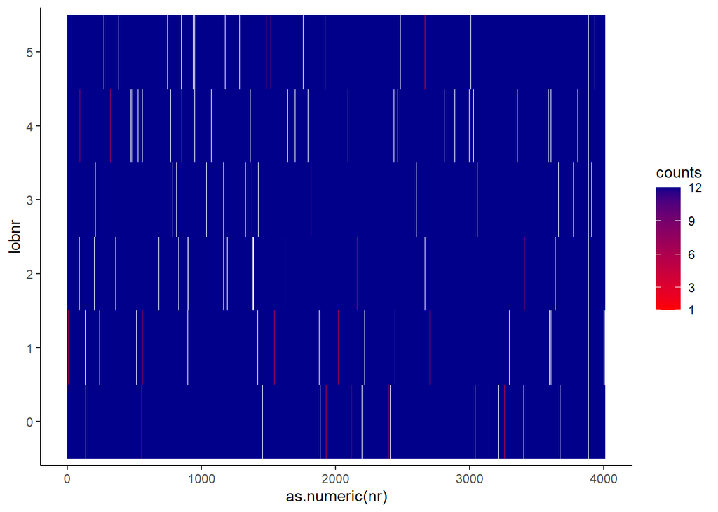

```r
# heat map to visualize missingness (white means missing)
exp_missing %>% ggplot(aes(as.numeric(nr), lobnr, fill= counts)) +
  geom_tile() +
  theme_classic() +
  scale_fill_gradient('counts', limits=c(1, 12), breaks = c(1, 3, 6, 9, 12),  low = "red", high = "darkblue")
```

# Explore missing data in the 5-year time window exposure and save the dataset

```r
# select the 5-years time window dataset
five_years <- filtered_data %>%
  dplyr::select(-data, -one_year, -ten_yr) %>%
  unnest(., cols = five_yr)

# check how many cases and controls total we have in this data set
case_num_5 <- five_years %>%
 dplyr::filter(ck == 1) %>% # selecting only cases
  count(nr) # count number of unique "nr" (cases)

# check how many controls total we have in this dataset
control_num_5 <- five_years %>%
  dplyr::filter(ck == 0) %>% # selecting controls
  group_by(nr) %>%
   count(lobnr)

# save the 5-years time window dataframe
#write_csv(five_years, paste0(robbie_datasets, "five_yrs_data.csv"))

# check how many cases/controls are missing months
exp_missing_5yrs <- five_years %>%
  group_by(nr, lobnr) %>%
  summarise(counts = n()) # minimum number of available months is 1
exp_missing_5yrs %>%
  tally(counts<12) %>%
  summarize(n=sum(n))
```

```
## # A tibble: 1 x 1
##       n
##   <int>
## 1    49
```

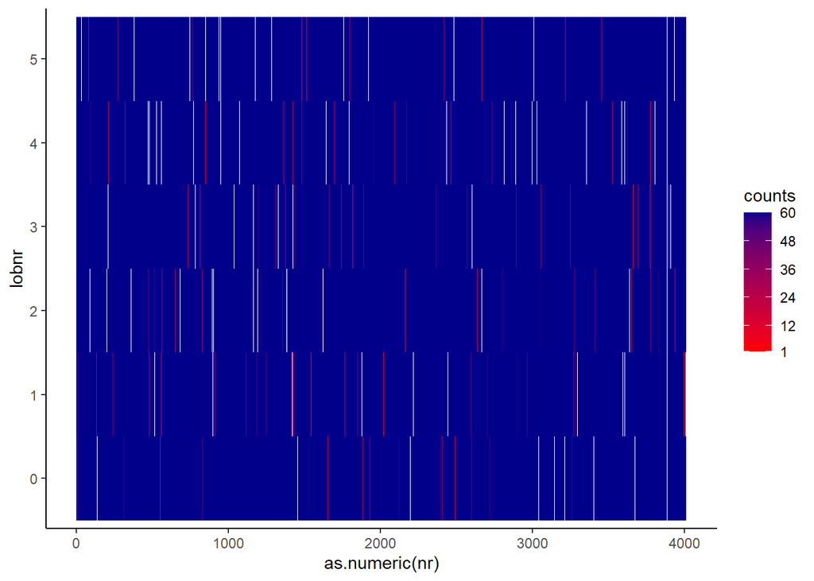

```r
# heat map to visualize missingness (white means missing)
exp_missing_5yrs %>% ggplot(aes(as.numeric(nr), lobnr, fill= counts)) +
  geom_tile() +
  theme_classic() +
  scale_fill_gradient('counts', limits=c(1, 60), breaks = c(1, 12, 24, 36, 48, 60),  low = "red", high = "darkblue")
```

# Explore missing data in the 10-year time window exposure and save the dataset

```r
# select the ten-years time window dataset
ten_years <- filtered_data %>%
  dplyr::select(-data, -one_year, -five_yr) %>%
  unnest(., cols = ten_yr)

# check how many cases total we have in this dataset
case_num_10 <- ten_years %>%
 dplyr::filter(ck == 1) %>% # selecting only cases
  count(nr) # count number of unique "nr" (cases)

# check how many controls total we have in this dataset
control_num_10 <- ten_years %>%
  dplyr::filter(ck == 0) %>% # selecting controls
  group_by(nr) %>%
   count(lobnr)

# save the 10-years time window dataframe
#write_csv(ten_years, paste0(robbie_datasets, "ten_yrs_data.csv"))

# check how many cases/controls are missing months
exp_missing_10yrs <- ten_years %>%
  group_by(nr, lobnr) %>%
  summarise(counts = n()) # minimum number of available months is 1
exp_missing_10yrs %>%
  tally(counts<12) %>%
  summarize(n=sum(n))
```

```
## # A tibble: 1 x 1
##       n
##   <int>
## 1    39
```

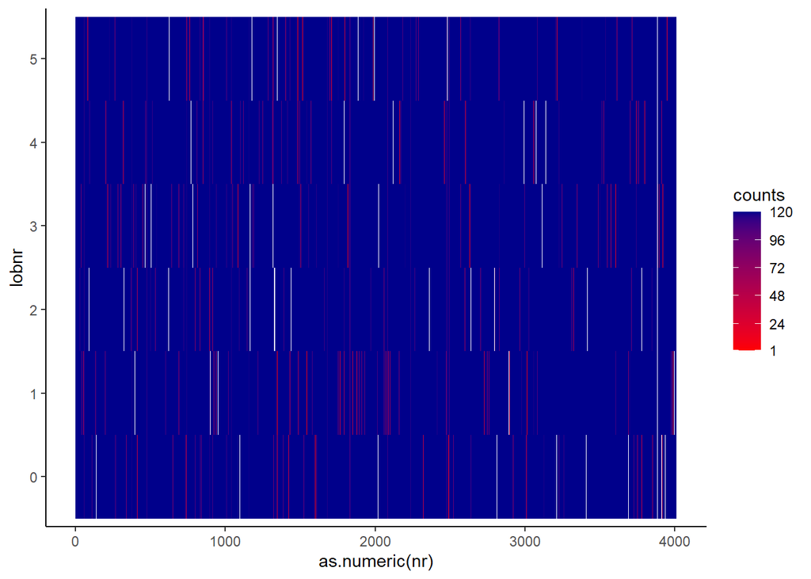

```r
# heat map to visualize missingness (white means missing)
exp_missing_10yrs %>% ggplot(aes(as.numeric(nr), lobnr, fill= counts)) + geom_tile() +
  theme_classic() +
  scale_fill_gradient('counts', limits=c(1, 120), breaks = c(1, 24, 48, 72, 96, 120),  low = "red", high = "darkblue")
```

~~~~~~~~~~~~~~~~~~~~~ Notes:

For the 1-year exposure window, limit cases and controls to those we have at least 75% of the pollutant measurements. That is, at least **9 out of the 12 months** need to have a pollutant measurement. Furthermore, within those 9 measurements we need to have at least one measure for each of the year seasons (Denmark has 4 seasons)

For the 5-years and 10-years exposure window, limit cases and controls to those we have at least 50% of the PM2.5 measurements. That is, for the 5-year time window at least **30 out of the 60 months** should have a measurement. For the 10-year window, each case/control should have at least 60 months with pollutant measurements out of the 120 months.

For all time windows, each case needs to have at least one control that fulfills the requirements described in the above text.

# Filtered cases/controls that satisfy the above requirements

# 1-year exposure windows

****** Check total number of cases *****

```r
filter_1yr <- one_year %>%
  group_by(nr, lobnr) %>%
  dplyr::mutate(months_meas = n()) %>%
  ungroup() %>%
  dplyr::filter(months_meas >= 9) %>% # select those with at least 9 months
  mutate(month_exp = month(date_exp),
         season = if_else(month_exp >=3 & month_exp <= 5, "spring",
                  if_else(month_exp >=6 & month_exp <=8, "summer",
                  if_else(month_exp >=9 & month_exp <= 11, "fall",
                  if_else(month_exp == 12 | month_exp <= 2, "winter", "x"))))) %>%  # season ID
  group_by(nr, lobnr) %>%
  mutate(season_num = length(unique(season))) %>% #XX entries are missing measurements in a season
ungroup() %>%
  dplyr::filter(season_num >= 4) %>% # filter for entries that have at least 1 measurement in each season
group_by(nr) %>%
  dplyr::mutate(case_control = length(unique(ck))) %>% # ID to check that each case has at least one control and that each control has a case
  dplyr::filter(case_control >= 2) %>% # filter cases that have  at least  one  control  and controls that have a  case
  ungroup() %>%
  dplyr::select(-month_exp, -months_meas, -season, -season_num, -case_control) # remove IDs

summary(filter_1yr)
```

```
##        nr         lobnr     ck            diagtype    diagdat
##  2      :    72   0:47295   0:232824   Min.   :1   Min.   :1989-01-02
##  3      :    72   1:46677   1: 47295   1st Qu.:1   1st Qu.:1997-06-06
##  4      :    72   2:46516              Median :1   Median :2003-11-25
##  5      :    72   3:46550              Mean   :1   Mean   :2003-02-13
##  6      :    72   4:46544              3rd Qu.:1   3rd Qu.:2009-02-19
##  7      :    72   5:46537              Max.   :1   Max.   :2013-12-30
##  (Other):279687
##     year_gap             one_year            five_years
##  Min.   :1988-01-02   Min.   :1987-01-02   Min.   :1983-01-02
##  1st Qu.:1996-06-06   1st Qu.:1995-06-06   1st Qu.:1991-06-06
##  Median :2002-11-25   Median :2001-11-25   Median :1997-11-25
##  Mean   :2002-02-13   Mean   :2001-02-13   Mean   :1997-02-13
##  3rd Qu.:2008-02-19   3rd Qu.:2007-02-19   3rd Qu.:2003-02-19
##  Max.   :2012-12-30   Max.   :2011-12-30   Max.   :2007-12-30
##
##    ten_years                ID         aegtesocial         bdate
##  Min.   :1978-01-02   Min.   :    9   Min.   :1.00     Min.   :1901-02-06
##  1st Qu.:1986-06-06   1st Qu.: 9643   1st Qu.:3.00     1st Qu.:1927-05-09
##  Median :1992-11-25   Median :19149   Median :4.00     Median :1936-11-01
##  Mean   :1992-02-13   Mean   :18967   Mean   :3.61     Mean   :1937-07-02
##  3rd Qu.:1998-02-19   3rd Qu.:28634   3rd Qu.:5.00     3rd Qu.:1946-04-01
##  Max.   :2002-12-30   Max.   :36806   Max.   :5.00     Max.   :1987-06-01
##                                       NA's   :109107
##   civst          civstdat5             d_inddto             d_uddto
##  1   : 25940   Min.   :1900-07-01   Min.   :1989-01-02   Min.   :1989-01-06
##  2   : 50674   1st Qu.:1960-09-30   1st Qu.:1997-06-06   1st Qu.:1997-09-30
##  3   : 32751   Median :1973-04-21   Median :2003-11-27   Median :2004-05-20
##  4   :170718   Mean   :1974-09-10   Mean   :2003-02-21   Mean   :2003-08-19
##  NA's:    36   3rd Qu.:1989-07-13   3rd Qu.:2009-03-04   3rd Qu.:2009-10-19
##                Max.   :2013-08-30   Max.   :2013-12-30   Max.   :2014-11-01
##                NA's   :25940
##     daars1             daars2               diag             diy
##  Length:280119      Length:280119      DG122  :218089   Min.   :1989
##  Class :character   Class :character   34809  : 30573   1st Qu.:1997
##  Mode  :character   Mode  :character   DG122G : 29549   Median :2003
##                                        DG122F :   636   Mean   :2003
##                                        DG122A :   360   3rd Qu.:2009
##                                        DG122D :   360   Max.   :2013
##                                        (Other):   552
```

[output cut: 33 more lines]

```
##  Min.   : 2.348   Min.   :  93.09   Min.   : 0.03276   Min.   : 1.481
##  1st Qu.: 9.228   1st Qu.: 159.95   1st Qu.: 0.46519   1st Qu.:12.251
##  Median :11.319   Median : 198.37   Median : 0.69267   Median :16.739
##  Mean   :11.990   Mean   : 224.52   Mean   : 0.81434   Mean   :18.244
##  3rd Qu.:14.124   3rd Qu.: 253.08   3rd Qu.: 1.01675   3rd Qu.:22.564
##  Max.   :51.340   Max.   :1879.16   Max.   :10.44558   Max.   :93.179
##
##     NOX_str            O3_str           PM10_str
##  Min.   :  1.692   Min.   :  1.675   Min.   : 5.693
##  1st Qu.: 13.923   1st Qu.: 39.352   1st Qu.:14.735
##  Median : 20.077   Median : 53.131   Median :17.616
##  Mean   : 25.742   Mean   : 52.555   Mean   :18.121
##  3rd Qu.: 29.863   3rd Qu.: 66.327   3rd Qu.:20.746
##  Max.   :373.362   Max.   :117.169   Max.   :57.628
##
```

```r
# final number of cases
length(unique(filter_1yr$nr))
```

```
## [1] 3942
```

```r
#final number of controls
filter_1yr %>%
  dplyr::filter(ck == 0) %>% #select controls only
  group_by(nr) %>%
 count(lobnr) %>%
  nrow()
```

```
## [1] 19406
```

```r
# save data
write_csv(filter_1yr, paste0(robbie_datasets, "one_yr_filtered_data.csv"))
```

# 5-years exposure windows

****** Check total number of cases *****

```r
filter_5yrs <- five_years %>%
  group_by(nr, lobnr) %>%
  dplyr::mutate(months_meas = n()) %>% #ID to check mounts measure
  ungroup() %>%
  dplyr::filter(months_meas >= 30) %>% # select those with at least 30 months
group_by(nr) %>%
  dplyr::mutate(case_control = length(unique(ck))) %>% # ID to check that each case has at least one control and that each control has a case
  dplyr::filter(case_control >= 2) %>%
  ungroup() %>%
  dplyr::select(-case_control, -months_meas) # remove IDs

summary(filter_5yrs)
```

```
##        nr          lobnr      ck             diagtype    diagdat
##  2      :    360   0:235921   0:1160982   Min.   :1   Min.   :1989-01-02
##  3      :    360   1:232951   1: 235921   1st Qu.:1   1st Qu.:1997-06-16
##  4      :    360   2:232058               Median :1   Median :2003-12-03
##  5      :    360   3:232040               Mean   :1   Mean   :2003-02-21
##  6      :    360   4:232063               3rd Qu.:1   3rd Qu.:2009-02-20
##  7      :    360   5:231870               Max.   :1   Max.   :2013-12-30
##  (Other):1394743
##     year_gap             one_year            five_years
##  Min.   :1988-01-02   Min.   :1987-01-02   Min.   :1983-01-02
##  1st Qu.:1996-06-16   1st Qu.:1995-06-16   1st Qu.:1991-06-16
##  Median :2002-12-03   Median :2001-12-03   Median :1997-12-03
##  Mean   :2002-02-21   Mean   :2001-02-21   Mean   :1997-02-21
##  3rd Qu.:2008-02-20   3rd Qu.:2007-02-20   3rd Qu.:2003-02-20
##  Max.   :2012-12-30   Max.   :2011-12-30   Max.   :2007-12-30
##
##    ten_years                ID         aegtesocial         bdate
##  Min.   :1978-01-02   Min.   :    9   Min.   :1.0      Min.   :1901-02-06
##  1st Qu.:1986-06-16   1st Qu.: 9665   1st Qu.:3.0      1st Qu.:1927-05-03
##  Median :1992-12-03   Median :19141   Median :4.0      Median :1936-11-01
##  Mean   :1992-02-22   Mean   :18969   Mean   :3.6      Mean   :1937-07-10
##  3rd Qu.:1998-02-20   3rd Qu.:28646   3rd Qu.:5.0      3rd Qu.:1946-04-01
##  Max.   :2002-12-30   Max.   :36806   Max.   :5.0      Max.   :1987-06-01
##                                       NA's   :543100
##   civst          civstdat5             d_inddto             d_uddto
##  1   :129240   Min.   :1900-07-01   Min.   :1989-01-02   Min.   :1989-01-06
##  2   :253427   1st Qu.:1960-10-12   1st Qu.:1997-06-16   1st Qu.:1997-10-09
##  3   :163258   Median :1973-05-05   Median :2003-12-11   Median :2004-06-08
##  4   :850858   Mean   :1974-09-19   Mean   :2003-03-01   Mean   :2003-08-28
##  NA's:   120   3rd Qu.:1989-07-15   3rd Qu.:2009-03-05   3rd Qu.:2009-10-21
##                Max.   :2013-08-30   Max.   :2013-12-30   Max.   :2014-11-01
##                NA's   :129240
##     daars1             daars2               diag              diy
##  Length:1396903     Length:1396903     DG122  :1088111   Min.   :1989
##  Class :character   Class :character   34809  : 151183   1st Qu.:1997
##  Mode  :character   Mode  :character   DG122G : 147708   Median :2003
##                                        DG122F :   3180   Mean   :2003
##                                        DG122A :   2132   3rd Qu.:2009
##                                        DG122D :   1798   Max.   :2013
##                                        (Other):   2791
```

[output cut: 33 more lines]

```
##  Min.   : 1.817   Min.   :  90.16   Min.   : 0.02886   Min.   : 1.084
##  1st Qu.: 9.666   1st Qu.: 166.29   1st Qu.: 0.48756   1st Qu.:12.801
##  Median :11.902   Median : 207.95   Median : 0.72280   Median :17.482
##  Mean   :12.613   Mean   : 237.68   Mean   : 0.85103   Mean   :18.921
##  3rd Qu.:14.884   3rd Qu.: 268.03   3rd Qu.: 1.06039   3rd Qu.:23.301
##  Max.   :88.284   Max.   :2129.13   Max.   :13.44768   Max.   :93.179
##
##     NOX_str            O3_str           PM10_str
##  Min.   :  1.166   Min.   :  1.005   Min.   :  4.443
##  1st Qu.: 14.603   1st Qu.: 38.370   1st Qu.: 15.203
##  Median : 21.204   Median : 52.341   Median : 18.146
##  Mean   : 27.214   Mean   : 51.930   Mean   : 18.762
##  3rd Qu.: 31.453   3rd Qu.: 65.977   3rd Qu.: 21.487
##  Max.   :373.362   Max.   :137.362   Max.   :106.936
##
```

```r
# final number of cases
length(unique(filter_5yrs$nr))
```

```
## [1] 3942
```

```r
#final number of controls
filter_5yrs %>%
  dplyr::filter(ck == 0) %>% #select controls only
  group_by(nr) %>%
 count(lobnr) %>%
  nrow()
```

```
## [1] 19398
```

```r
# save data
write_csv(filter_5yrs, paste0(robbie_datasets, "five_yrs_filtered_data.csv"))
```

# 10-years exposure window

****** Check total number of cases *****

```r
filter_10yrs <- ten_years %>%
  group_by(nr, lobnr) %>%
  dplyr::mutate(months_meas = n()) %>% #ID to check months measure
  ungroup() %>%
  dplyr::filter(months_meas >= 60) %>% # select those with at least 60 months
group_by(nr) %>%
  dplyr::mutate(case_control = length(unique(ck))) %>% # ID to check that each case has at least one control and that each control has a case
  dplyr::filter(case_control >= 2) %>%
  ungroup() %>%
  dplyr::select(-case_control, -months_meas) # remove ID

summary(filter_10yrs)
```

```
##        nr          lobnr      ck             diagtype    diagdat
##  2      :    720   0:470064   0:2310637   Min.   :1   Min.   :1989-01-02
##  3      :    720   1:462959   1: 470064   1st Qu.:1   1st Qu.:1997-06-19
##  4      :    720   2:461719               Median :1   Median :2003-12-08
##  5      :    720   3:462590               Mean   :1   Mean   :2003-02-27
##  6      :    720   4:461738               3rd Qu.:1   3rd Qu.:2009-02-23
##  7      :    720   5:461631               Max.   :1   Max.   :2013-12-30
##  (Other):2776381
##     year_gap             one_year            five_years
##  Min.   :1988-01-02   Min.   :1987-01-02   Min.   :1983-01-02
##  1st Qu.:1996-06-19   1st Qu.:1995-06-19   1st Qu.:1991-06-19
##  Median :2002-12-08   Median :2001-12-08   Median :1997-12-08
##  Mean   :2002-02-27   Mean   :2001-02-26   Mean   :1997-02-26
##  3rd Qu.:2008-02-23   3rd Qu.:2007-02-23   3rd Qu.:2003-02-23
##  Max.   :2012-12-30   Max.   :2011-12-30   Max.   :2007-12-30
##
##    ten_years                ID         aegtesocial          bdate
##  Min.   :1978-01-02   Min.   :    9   Min.   :1.0       Min.   :1901-02-06
##  1st Qu.:1986-06-19   1st Qu.: 9690   1st Qu.:3.0       1st Qu.:1927-05-05
##  Median :1992-12-08   Median :19129   Median :4.0       Median :1936-11-02
##  Mean   :1992-02-27   Mean   :18977   Mean   :3.6       Mean   :1937-07-11
##  3rd Qu.:1998-02-23   3rd Qu.:28650   3rd Qu.:5.0       3rd Qu.:1946-04-01
##  Max.   :2002-12-30   Max.   :36806   Max.   :5.0       Max.   :1987-06-01
##                                       NA's   :1077790
##   civst           civstdat5             d_inddto             d_uddto
##  1   : 257671   Min.   :1900-07-01   Min.   :1989-01-02   Min.   :1989-01-06
##  2   : 504952   1st Qu.:1960-10-12   1st Qu.:1997-06-19   1st Qu.:1997-10-24
##  3   : 324716   Median :1973-04-25   Median :2003-12-22   Median :2004-06-10
##  4   :1693122   Mean   :1974-09-18   Mean   :2003-03-06   Mean   :2003-09-02
##  NA's:    240   3rd Qu.:1989-07-13   3rd Qu.:2009-03-10   3rd Qu.:2009-10-21
##                 Max.   :2013-08-30   Max.   :2013-12-30   Max.   :2014-11-01
##                 NA's   :257671
##     daars1             daars2               diag              diy
##  Length:2780701     Length:2780701     DG122  :2165157   Min.   :1989
##  Class :character   Class :character   34809  : 300345   1st Qu.:1997
##  Mode  :character   Mode  :character   DG122G : 295375   Median :2003
##                                        DG122F :   6360   Mean   :2003
##                                        DG122A :   4277   3rd Qu.:2009
##                                        DG122D :   3595   Max.   :2013
##                                        (Other):   5592
```

[output cut: 33 more lines]

```
##  Min.   : 1.817   Min.   :  90.16   Min.   : 0.02886   Min.   : 1.084
##  1st Qu.:10.098   1st Qu.: 173.70   1st Qu.: 0.50966   1st Qu.:13.311
##  Median :12.616   Median : 219.07   Median : 0.75086   Median :18.164
##  Mean   :13.409   Mean   : 253.20   Mean   : 0.88650   Mean   :19.532
##  3rd Qu.:15.912   3rd Qu.: 286.77   3rd Qu.: 1.09968   3rd Qu.:24.016
##  Max.   :88.284   Max.   :2410.44   Max.   :15.48087   Max.   :99.953
##
##     NOX_str            O3_str            PM10_str
##  Min.   :  1.166   Min.   :  0.6903   Min.   :  4.238
##  1st Qu.: 15.280   1st Qu.: 37.3292   1st Qu.: 15.775
##  Median : 22.301   Median : 51.6344   Median : 18.807
##  Mean   : 28.614   Mean   : 51.3390   Mean   : 19.547
##  3rd Qu.: 33.021   3rd Qu.: 65.7141   3rd Qu.: 22.436
##  Max.   :373.362   Max.   :144.9146   Max.   :106.936
##
```

```r
# final number of cases
length(unique(filter_10yrs$nr))
```

```
## [1] 3938
```

```r
#final number of controls
filter_10yrs %>%
 dplyr::filter(ck == 0) %>% #select controls only
  group_by(nr) %>%
 count(lobnr) %>%
  nrow()
```

```
## [1] 19362
```

```r
# save data
write_csv(filter_10yrs, paste0(robbie_datasets, "ten_yrs_filtered_data.csv"))
```